# Homework1

Yusuf Uluçoban - Spring 2021 - IE360

17 04 2021

# Data Visualization and Google Trends on Three Different Measures from Turkey

## 1) Monthly House Sales Data of Turkey from 2016 to 2021

This data set involves monthly reported house sales from every city in Turkey. The data is avaliable from January 2016 to January 2021, since the visualization goal is examining the trends on last 5 years. Because the data is accurate for each city, to examine and visualize for each is difficult to consider. To make things easier, the house sales data will be collected and controlled over three major cities in Turkey, İstanbul, Ankara and İzmir. Additionally, the total sales over Turkey will be included to further investigations.

```
##         Date  Total Ankara Istanbul Izmir season
## 1 2016-01-01  84556   9012    15526  5243 Winter
## 2 2016-02-01 101703  10694    18142  6480 Winter
## 3 2016-03-01 117205  12730    21993  7549 Spring
## 4 2016-04-01 106348  11843    19537  6568 Spring
## 5 2016-05-01 114800  11408    21638  6697 Spring
## 6 2016-06-01 106187  11695    20406  6745 Summer
```

As you can observe, data frame includes date column for each month, total column for the all sales in the country and three different columns for three different major cities in Turkey. The numbers shows the number of house sales.

Let’s plot all the observations according to monthly time frames.

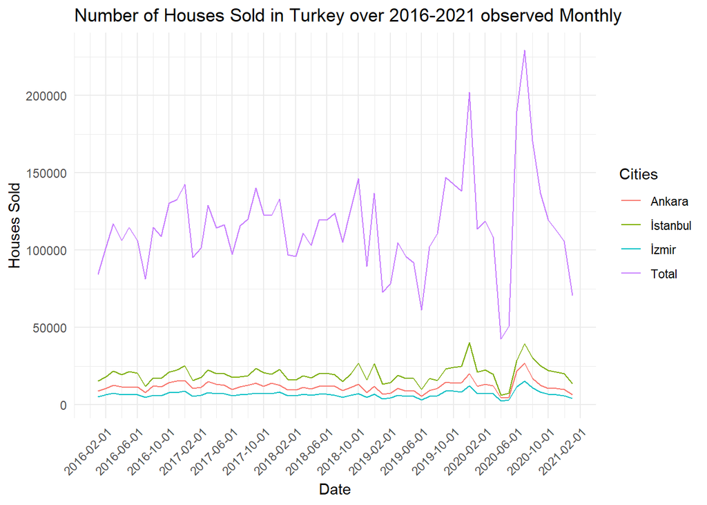

It is obvious that the sales amounts has some oscillations throughout the time although the trend seems increasing. For further calculations and investigations, looking up to the years to learn if is there a similar pattern for each years such as, all has the maximum in winter or minimum in summer etc.

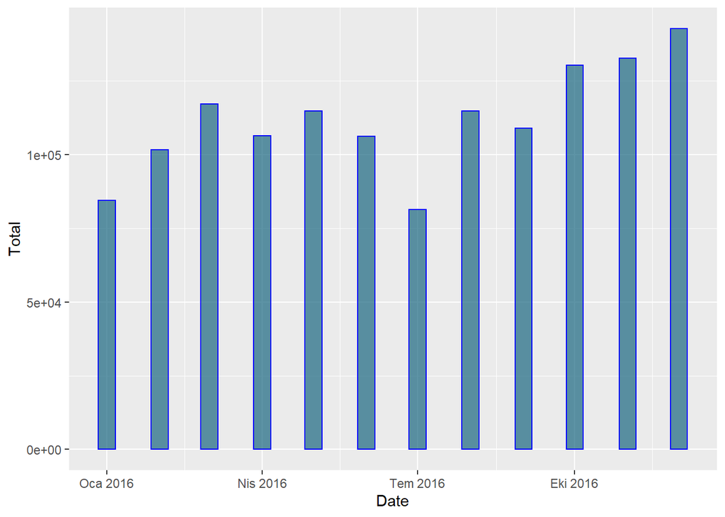

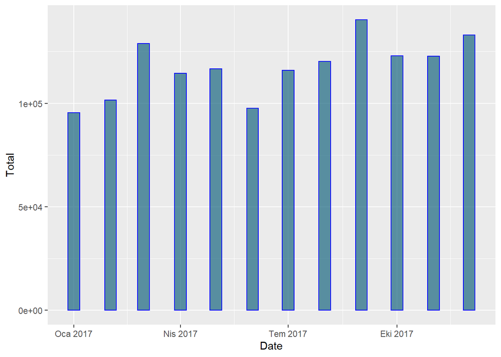

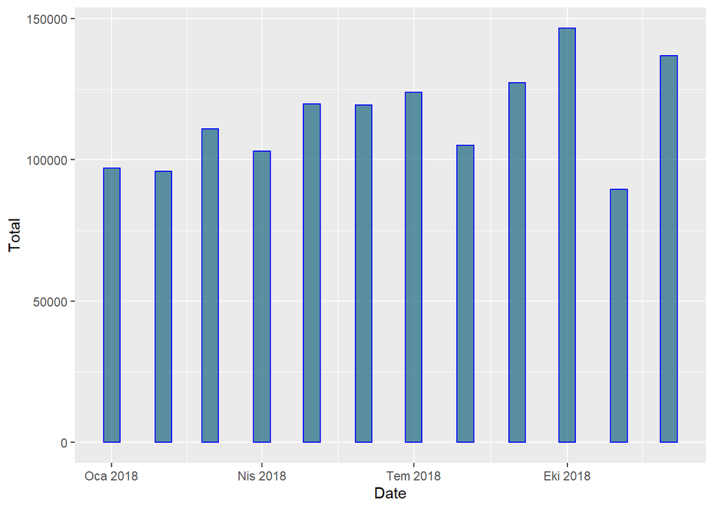

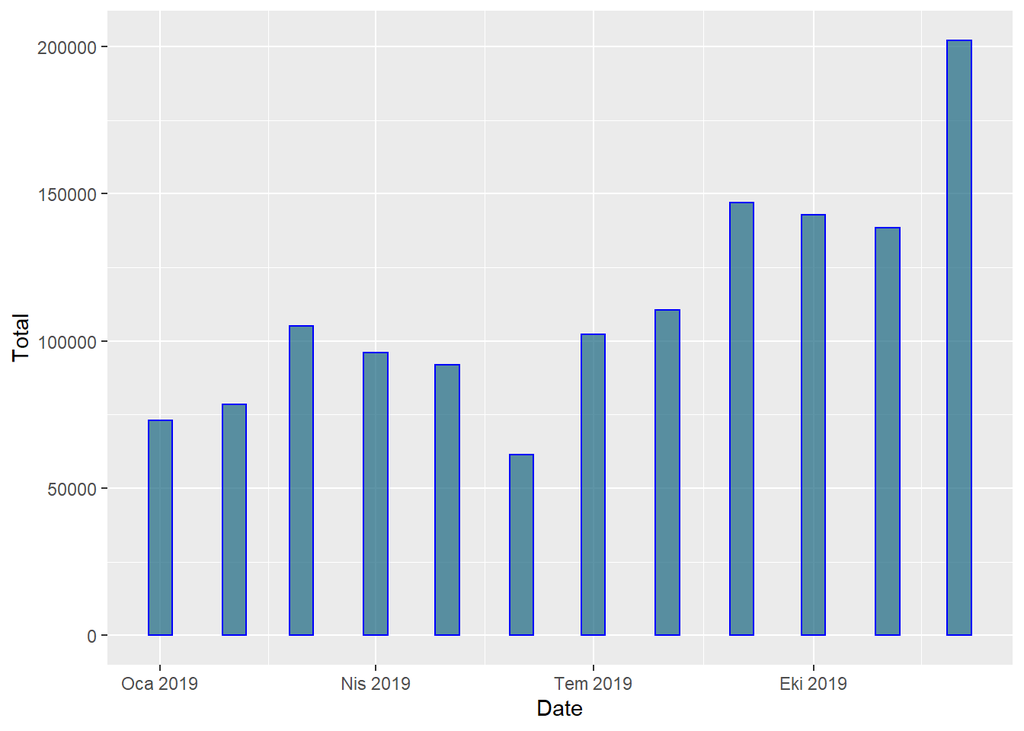

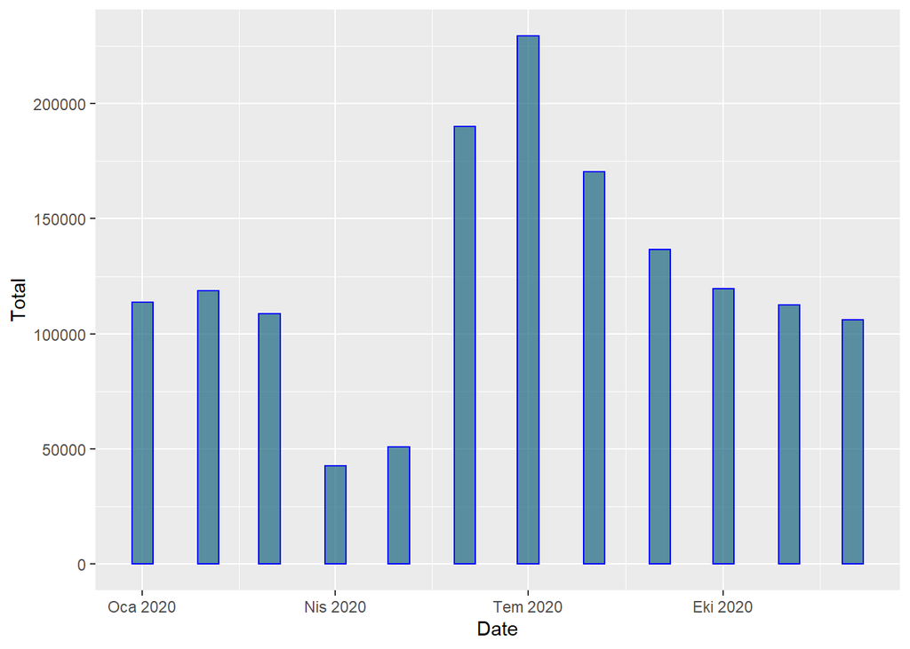

Firstly, although it seems that the amount of house sales is decreasing in the last two years, it is incorrect. Since the numbers of y axises are not equal, graphs may mislead us about the trend. The goal was the examine a similar trend for each year. As you can observe, it can be said that, spring sales are less than autumn sales. Also, sales are generally has increased in late summer. Usually, after the June, the sales has an increasing trend. As a result we can say that, people usually buy houses in the late summer and autumn but not in spring. For another clear visualization of this seasonal trend, that increases in late summer and autumn, the boxplot of seasonal sales can be considered.

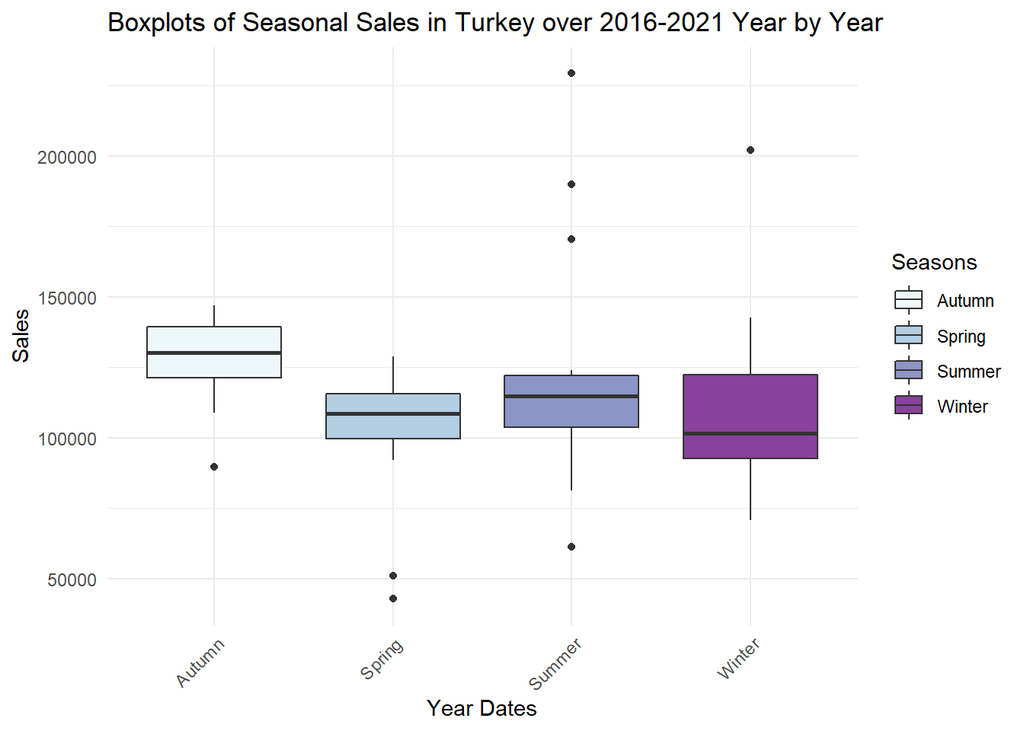

For a clear last step, boxplot of the house sales in the last 5 years are shown below.

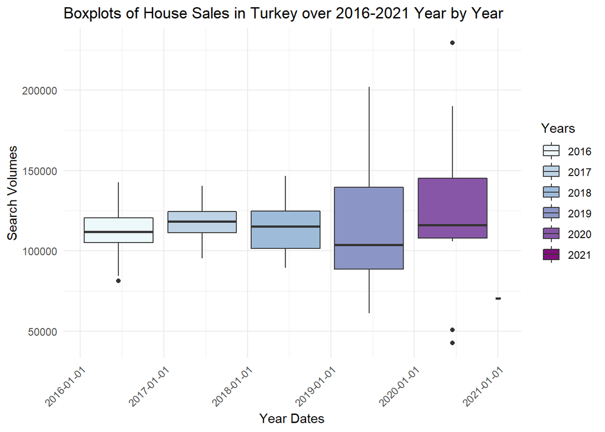

As you can observe, the increasing trend continues although the lowest sales in the corona pandemic that are shown as double dots in the year 2020.

From now on, Google trends data will help us to find a correlation between the key word “satılık ev” with house sales data.

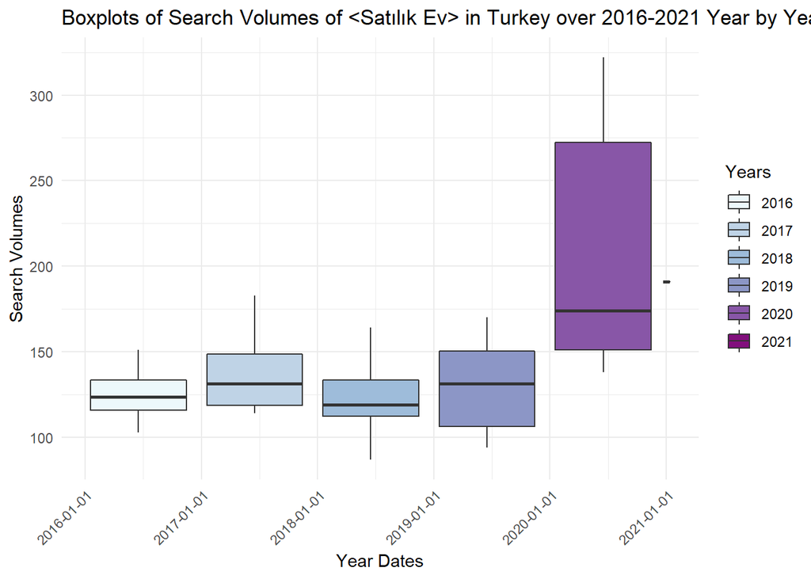

As it is guessed, the graphs look similar. With the effects of the corona-virus pandemic that is started at 03.2020, the searches for house sales in Google has increased in the year 2020, however the amount of sales did not increased accordingly. The graphs of the remaining years are correlated.

## 2) Dollar and Euro Exchange Rates with the Searches on Google

```
##         Date    USD   EURO
## 2 2018-01-02 3.7719 4.5155
## 3 2018-01-03 3.7652 4.5375
## 4 2018-01-04 3.7617 4.5267
## 5 2018-01-05 3.7600 4.5269
## 8 2018-01-08 3.7456 4.5144
## 9 2018-01-09 3.7454 4.4930
```

Since the stock market are closed in the weekends, the numeric exchange values were shown as Null’s, so the weekend rows are deleted.

Firstly, let’s analyze the line plot of the USD/TRY and Euro/TRY for the last 3 years.

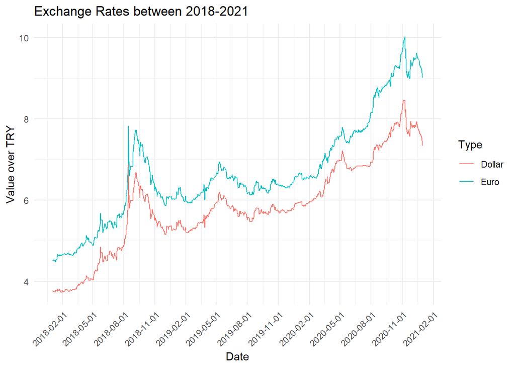

Although they have some differences such as in the June-July of 2020 time frame; since both has a TRY in the denominator, they usually moved together. So, it can be said that these two are correlated. For further analyses, it is better that analyze box-plot graphs rather than line plots.

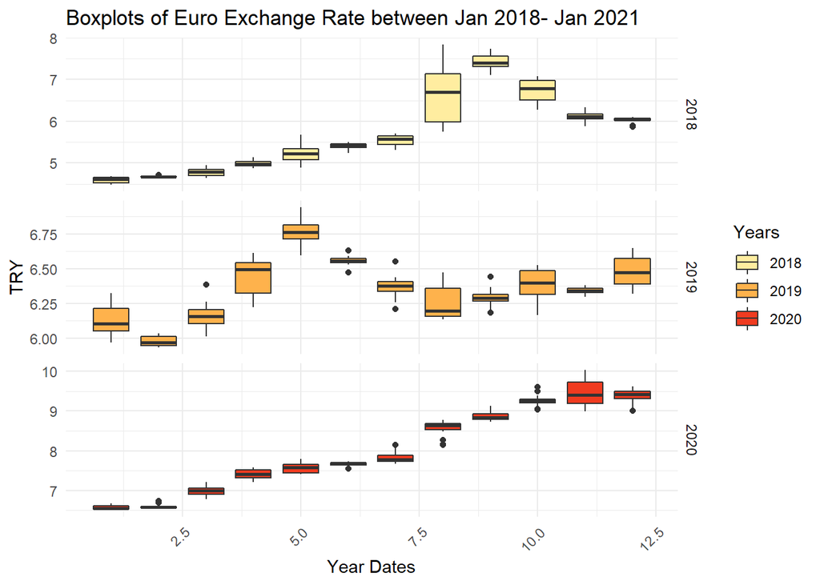

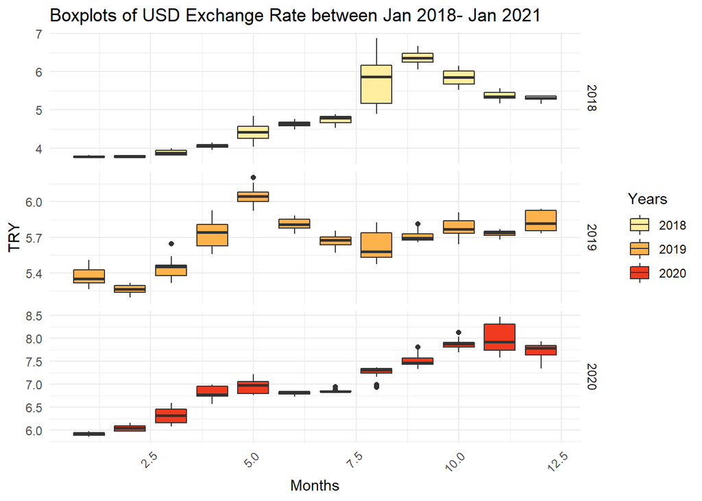

It is very clear that Euro and Dollar rates move together according to Turkish Lira. Since it is an economic and governmental situation, things that make Turkey economics lead worse, lead exchange rates upwards. Comparing the results with the Google searches would be wise. For example, let’s investigate key word “1 Dolar” in Google Trends. Because Google has a currency converter, people may be searching for the answer in Google.

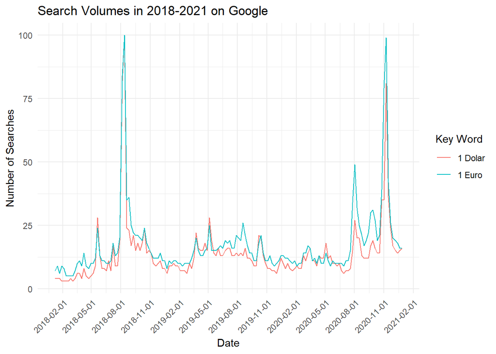

## 3) The Closing Value of BIST(Turkish Stock Market) and Effects on Google Searches

In the last time series of the homework, the stock market values and their effects on Google search will be investigated. Since there are rows with Null values because of the bank holidays, the null rows will be deleted to reach a better point to visualize.

```
##         Date    Value Year Month
## 2 2018-01-02 1175.242 2018     1
## 3 2018-01-03 1160.522 2018     1
## 4 2018-01-04 1154.912 2018     1
## 5 2018-01-05 1166.379 2018     1
## 7 2018-01-09 1150.228 2018     1
## 8 2018-01-10 1135.895 2018     1
```

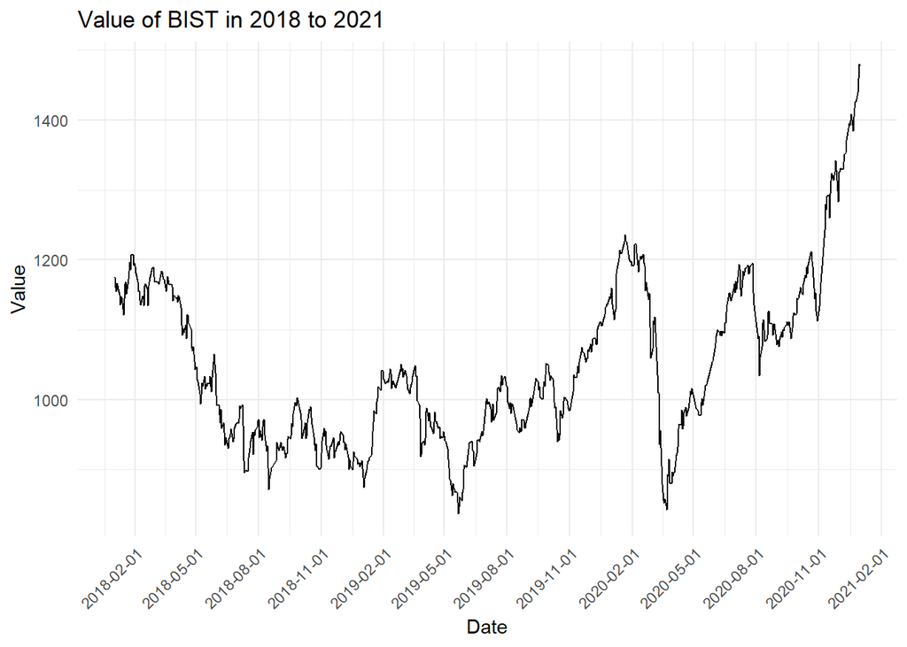

As you can observe, there are lots of oscillations through time. However, finding a increasing or decreasing trend from this line plot is not easy. For further analysis, examining the box plot would be better.

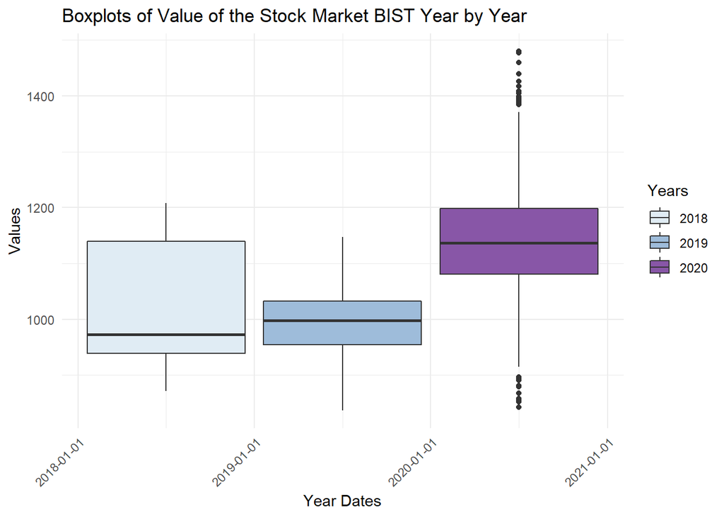

It is obvious that there are not an any absolute trend, but with the corona virus pandemic it can be seen that year 2020 has lots of outliers. To conclude the results, looking for a correlation between Values and Google Searches would help.

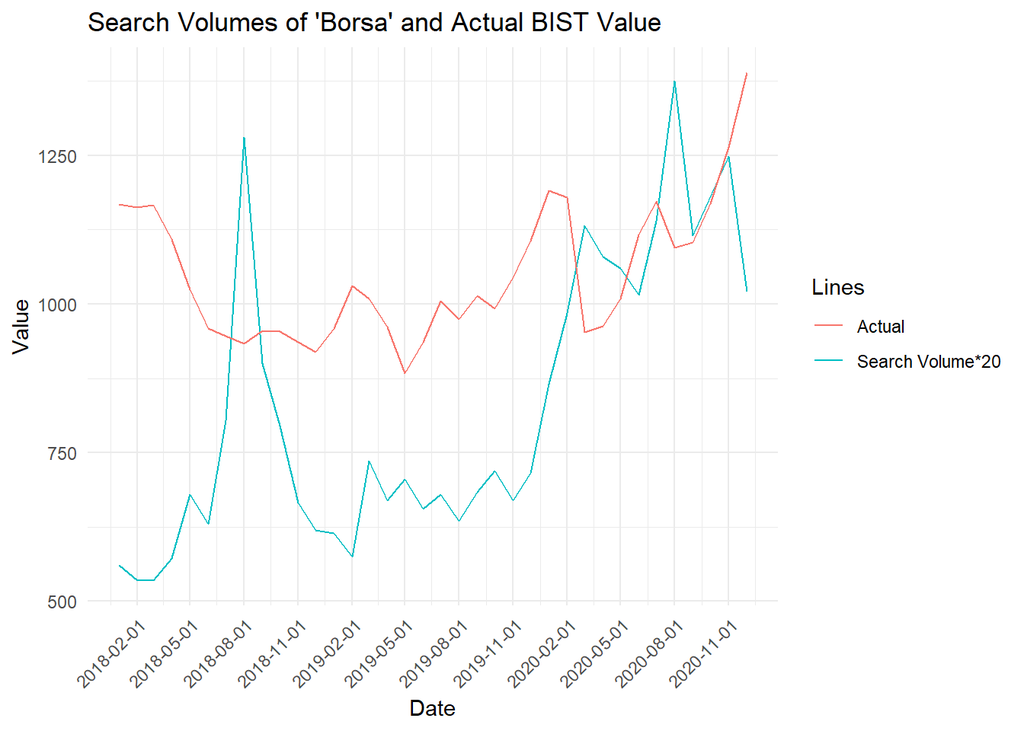

Since comparing two thing that are not measured together is hard, such as Google Trends data with 0-100 frame and BIST Value with higher results. To make things easier, we multiplied Google Trend data with 20. However, the result came different from what we expected. These two lines are not looking much correlated. There are some increasing and decreasing together but not much.

To conclude, although the first two case has some correlations with Google trends data, we have failed to find a correlation with the BIST values and Google Searches.

To compare three different time series with each other, we have to modify the values of the BIST, exchange rates and house sales.

```
## # A tibble: 6 x 6
## # Groups:   Year [1]
##    Year Month   usd  konut  bist Date
##   <dbl> <dbl> <dbl>  <dbl> <dbl> <date>
## 1  2018     1  3.77  97019 1168. 2018-01-01
## 2  2018     2  3.78  95953 1162. 2018-02-01
## 3  2018     3  3.88 110905 1167. 2018-03-01
## 4  2018     4  4.05 103087 1108. 2018-04-01
## 5  2018     5  4.41 119655 1025. 2018-05-01
## 6  2018     6  4.63 119413  959. 2018-06-01
```

As you can guess, we again have to change some values to see result in the same graph.

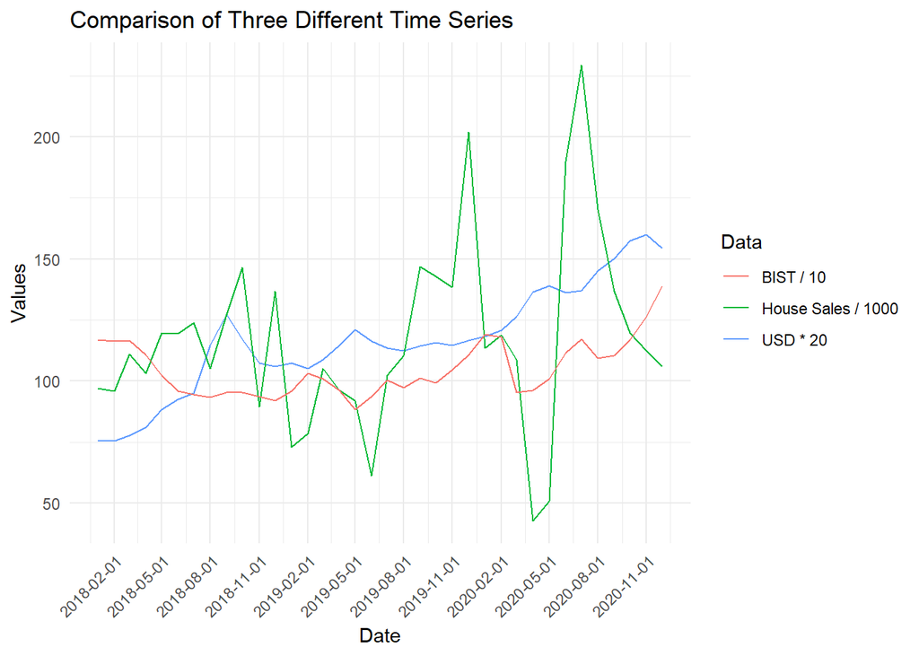

# Appendices

[Here](https://bu-ie-360.github.io/spring21-yulucoban/files/hw1.Rmd) the RMD File including the code chunks can be found.